```python
import numpy as np
import pandas as pd
from featexp import get_univariate_plots
from sklearn.linear_model import LogisticRegression
from sklearn.feature_selection import SequentialFeatureSelector
from sklearn.model_selection import train_test_split
from sklearn.metrics import roc_auc_score
import scorecardpy as sc
```

# Budowa modelu scoringowego

**Joanna Pokora**

## Wstęp

Celem raportu jest budowa modelu regresji logistycznej, przewidującego, czy w ciągu najbliższych dwóch lat klient doświadczy poważnych trudności w spłacie kredytu. Na podstawie tego modelu utworzona zostanie karta scoringowa, służąca do podejmowania decyzji o akceptacji lub odrzuceniu wniosku kredytowego. Dane wykorzystane w analizie pochodzą z konkursu Give Me Some Credit z platformy Kaggle.

```python
dat = pd.read_csv("C:/Users/Baller/Desktop/magisterka/bankowosc/raport4/cs-training.csv", sep = ",")
dat.drop("Unnamed: 0", axis = 1, inplace = True)
dat.shape
```

```
(150000, 11)
```

## Analiza eksploracyjna

Zbiór danych zawiera 150 000 obserwacji oraz 11 zmiennych:

- SeriousDlqin2yrs - czy klient spóźnił się z płatnością co najmniej 90 dni w ciągu kolejnych dwóch lat (binarna),
- RevolvingUtilizationOfUnsecuredLines - stosunek wykorzystanego limitu do dostępnego limitu na kartach kredytowych i liniach kredytowych, z wyłączeniem kredytów hipotecznych i ratalnych (w procentach),
- age - wiek,
- NumberOfTime30-59DaysPastDueNotWorse - liczba spóźnień z płatnością w granicach 30-59 dni w ciągu ostatnich dwóch lat,
- DebtRatio - stosunek miesięcznych zobowiązań (raty kredytów, alimenty, koszty życia) do miesięcznego dochodu (w procentach),
- MonthlyIncome - miesięczny przychód,
- NumberOfOpenCreditLinesAndLoans - liczba aktywnych kredytów oraz kont kredytowych,
- NumberOfTimes90DaysLate - liczba spóźnień z płatnością o co najmniej 90 dni,
- NumberRealEstateLoansOrLines - liczba kredytów hipotecznych,
- NumberOfTime60-89DaysPastDueNotWorse - liczba spóźnień z płatnością w granicach 60-89 dni w ciągu ostatnich dwóch lat,
- NumberOfDependents - liczba osób na utrzymaniu (nie licząc klienta).

Poniżej przedstawione zostały zliczenia brakujących wartości w każdej zmiennej.

```python
dat.isna().sum()
```

```
SeriousDlqin2yrs                            0
RevolvingUtilizationOfUnsecuredLines        0
age                                         0
NumberOfTime30-59DaysPastDueNotWorse        0
DebtRatio                                   0
MonthlyIncome                           29731
NumberOfOpenCreditLinesAndLoans             0
NumberOfTimes90DaysLate                     0
NumberRealEstateLoansOrLines                0
NumberOfTime60-89DaysPastDueNotWorse        0
NumberOfDependents                       3924
dtype: int64
```

Wartości brakujące występują jedynie w zmiennych MonthlyIncome oraz NumberOfDependents. W obu przypadkach może to wynikać na przykład z braku informacji lub nieustandaryzowanego systemu wprowadzania danych (na przykład, brak dochodu raz może być oznaczony jako 0, a raz jako wartość brakująca). Obserwacje z wartościami brakującymi zostaną wykluczone przy budowie modelu, na razie jednak pozostawiamy je w zbiorze.

Poniżej przedstawione zostały podstawowe informacje na temat rozkładu wartości każdej zmiennej.

```python
dat.describe()
```

|  | SeriousDlqin2yrs | RevolvingUtilizationOfUnsecuredLines | age | NumberOfTime30-59DaysPastDueNotWorse | DebtRatio | MonthlyIncome | NumberOfOpenCreditLinesAndLoans | NumberOfTimes90DaysLate | NumberRealEstateLoansOrLines | NumberOfTime60-89DaysPastDueNotWorse | NumberOfDependents |
| --- | --- | --- | --- | --- | --- | --- | --- | --- | --- | --- | --- |
| count | 150000.000000 | 150000.000000 | 150000.000000 | 150000.000000 | 150000.000000 | 1.202690e+05 | 150000.000000 | 150000.000000 | 150000.000000 | 150000.000000 | 146076.000000 |
| mean | 0.066840 | 6.048438 | 52.295207 | 0.421033 | 353.005076 | 6.670221e+03 | 8.452760 | 0.265973 | 1.018240 | 0.240387 | 0.757222 |
| std | 0.249746 | 249.755371 | 14.771866 | 4.192781 | 2037.818523 | 1.438467e+04 | 5.145951 | 4.169304 | 1.129771 | 4.155179 | 1.115086 |
| min | 0.000000 | 0.000000 | 0.000000 | 0.000000 | 0.000000 | 0.000000e+00 | 0.000000 | 0.000000 | 0.000000 | 0.000000 | 0.000000 |
| 25% | 0.000000 | 0.029867 | 41.000000 | 0.000000 | 0.175074 | 3.400000e+03 | 5.000000 | 0.000000 | 0.000000 | 0.000000 | 0.000000 |
| 50% | 0.000000 | 0.154181 | 52.000000 | 0.000000 | 0.366508 | 5.400000e+03 | 8.000000 | 0.000000 | 1.000000 | 0.000000 | 0.000000 |
| 75% | 0.000000 | 0.559046 | 63.000000 | 0.000000 | 0.868254 | 8.249000e+03 | 11.000000 | 0.000000 | 2.000000 | 0.000000 | 1.000000 |
| max | 1.000000 | 50708.000000 | 109.000000 | 98.000000 | 329664.000000 | 3.008750e+06 | 58.000000 | 98.000000 | 54.000000 | 98.000000 | 20.000000 |

Minimalna wartość zmiennej age wynosi 0. Sprawdźmy więc, ilu klientów ma wiek poniżej 18 lat.

```python
(dat.age < 18).value_counts()
```

```
False    149999
True          1
Name: age, dtype: int64
```

Wiek jest mniejszy niż 18 (równy 0) w przypadku tylko jednej obserwacji. Możemy więc uznać to za błąd przy wprowadzaniu danych i usunąć tego klienta.

Ponieważ w danych nie mamy unikalnego identyfikatora klienta, to usuwamy powtarzające się obserwacje. Nie wniosłyby one nowych informacji do modelu, natomiast w ten sposób wykluczamy ryzyko wielokrotnego brania pod uwagę tego samego klienta.

```python
dat = dat.query("age >= 18").reset_index(drop = True)
dat.drop_duplicates(inplace = True)
dat.shape
```

```
(149390, 11)
```

Po modyfikacjach, dane zawierają 149 390 obserwacji.

## Podział danych na zbiory treningowy i testowy

Dane dzielimy na zbiór treningowy i testowy, stanowiący 30% całości.

```python
X_train, X_test, y_train, y_test = train_test_split(dat[[i for i in dat.columns if i != "SeriousDlqin2yrs"]],
                                                    dat["SeriousDlqin2yrs"],
                                                    test_size = 0.3,
                                                    random_state = 42)
```

```
                            Plots for RevolvingUtilizationOfUnsecuredLines
                                           Train data plots
```

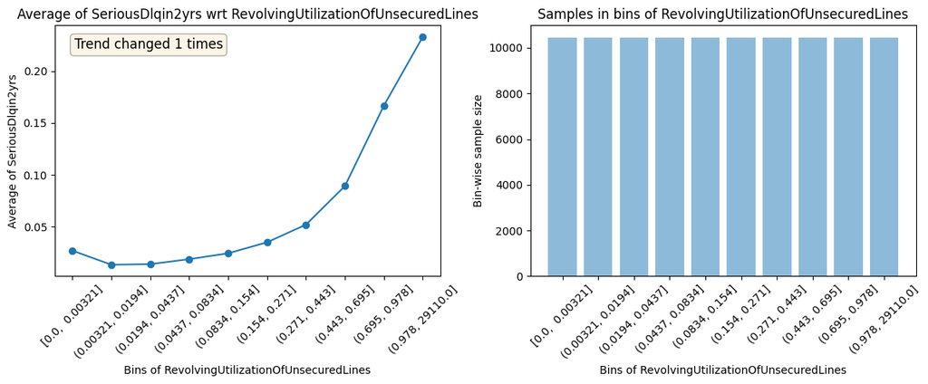

```
                                           Test data plots
```

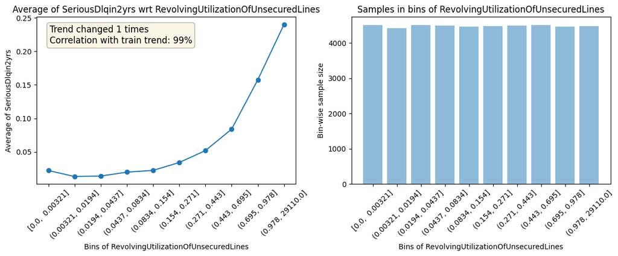

```
--------------------------------------------------------------------------------------------------------------


                                            Plots for age
                                           Train data plots
```

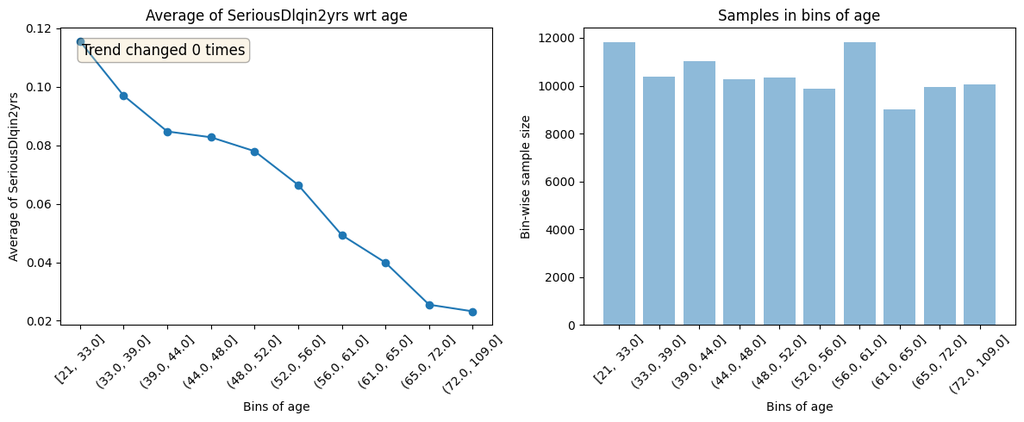

```
                                           Test data plots
```

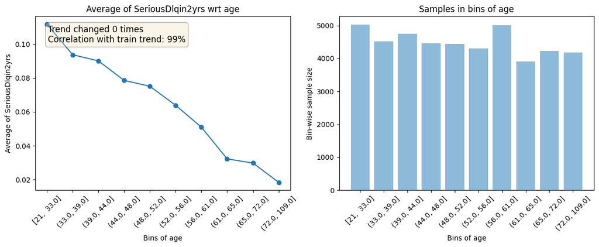

```
--------------------------------------------------------------------------------------------------------------


                            Plots for NumberOfTime30-59DaysPastDueNotWorse
                                           Train data plots
```

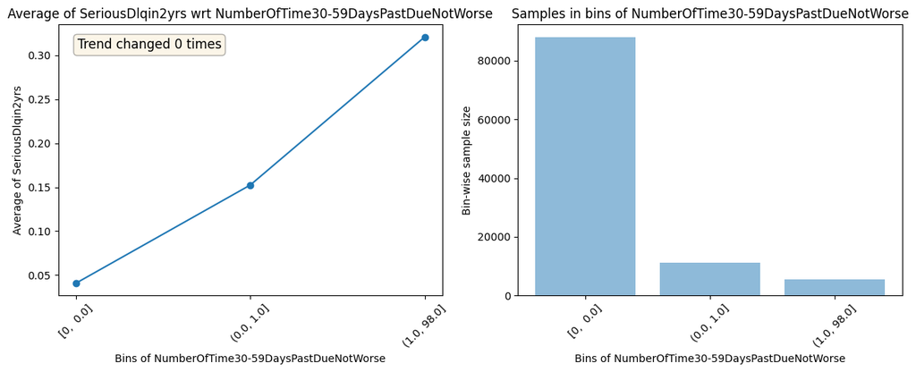

```
                                           Test data plots
```

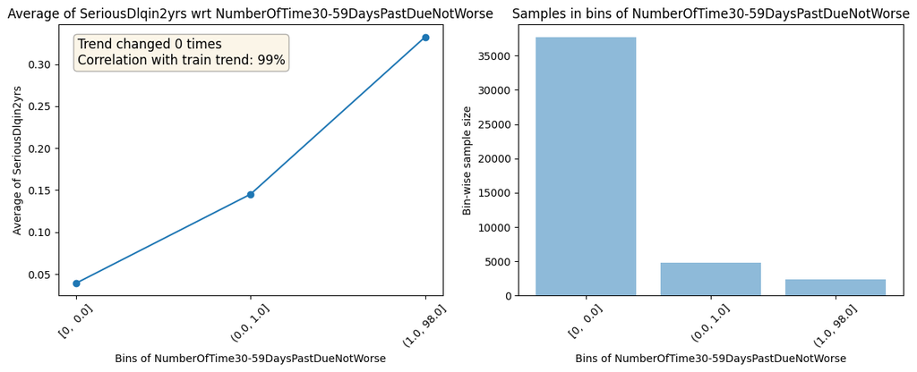

```
--------------------------------------------------------------------------------------------------------------


                                         Plots for DebtRatio
                                           Train data plots
```

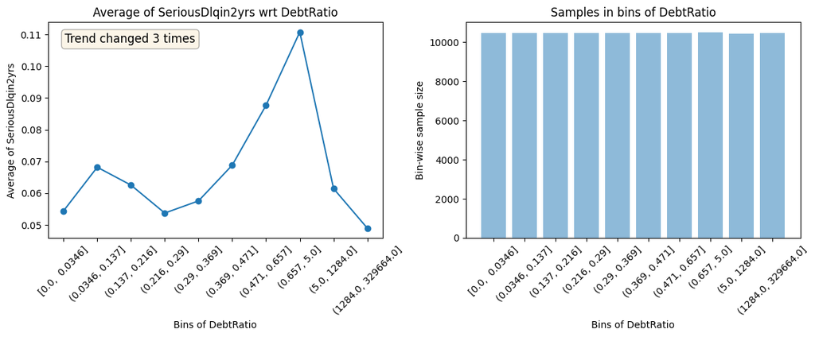

```
                                           Test data plots
```

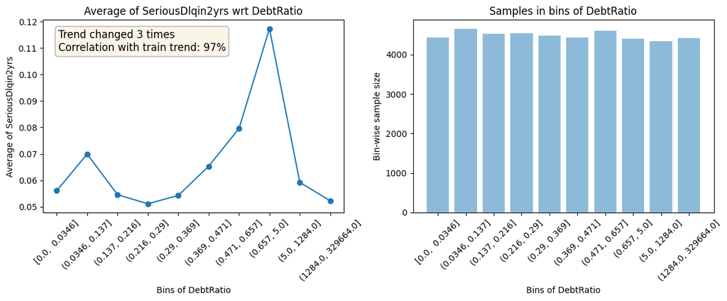

```
--------------------------------------------------------------------------------------------------------------


                                       Plots for MonthlyIncome
                                           Train data plots
```

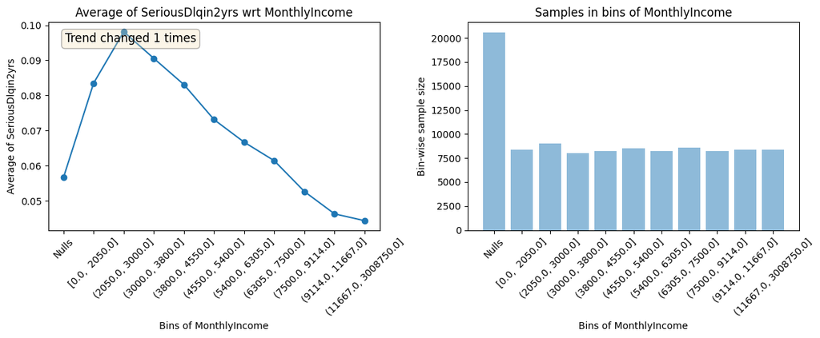

```
                                           Test data plots
```

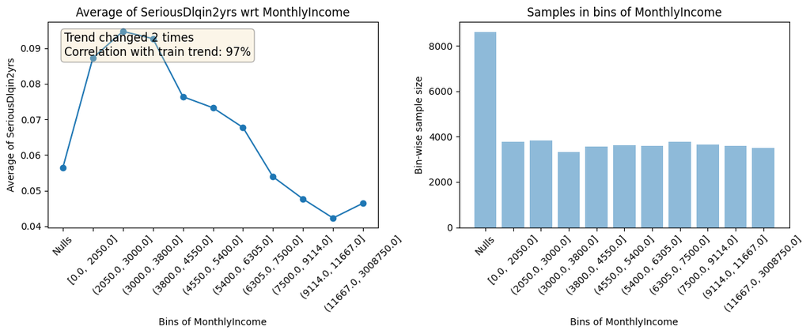

```
--------------------------------------------------------------------------------------------------------------


                              Plots for NumberOfOpenCreditLinesAndLoans
                                           Train data plots
```

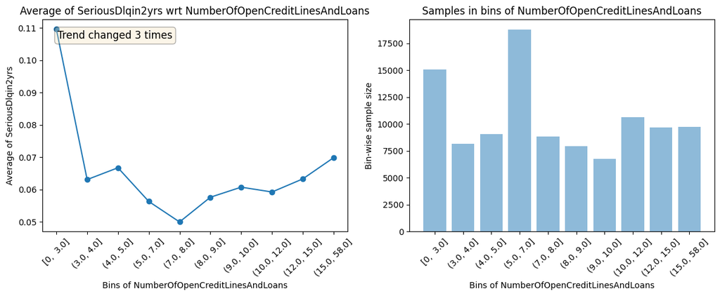

```
                                           Test data plots
```

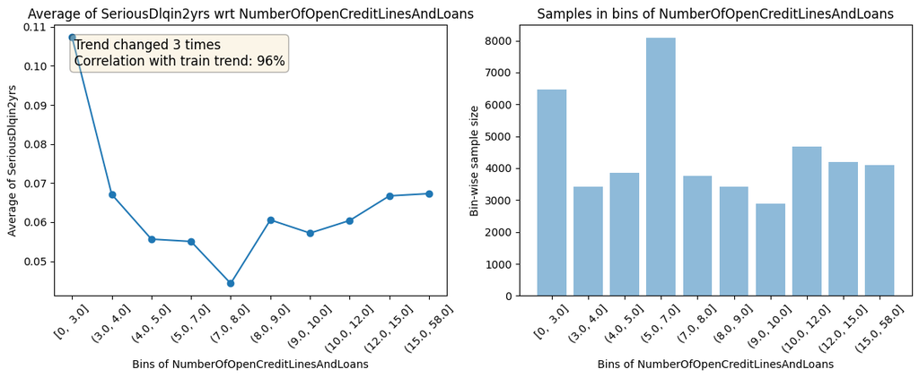

```
--------------------------------------------------------------------------------------------------------------


                                  Plots for NumberOfTimes90DaysLate
                                           Train data plots
```

[8 more figures not shown]

```python
get_univariate_plots(data = X_train.merge(y_train, left_index = True, right_index = True, how = "left"),
                     target_col = "SeriousDlqin2yrs",
                     data_test = X_test.merge(y_test, left_index = True, right_index = True, how = "left"))
```

Dla każdej zmiennej, oba wykresy są podobne dla zbiorów testowych i treningowych. Możemy więc przyjąć, że podzbiory te są reprezentatywne względem całości danych.

Wykresów przedstawiające rozkład pogrupowanych wartości zmiennych sugerują, że braki monotoniczności nie wynikają ze sposobu podziały na grupy. W przypadkach kiedy liczności w poszczególnych przedziałach są nieregularne, odchylenia liczby obserwacji nie pokrywają się z miejscami zmian trendu.

Kolejne analizy przeprowadzone zostaną jedynie na danych treningowych. Na początek, przeanalizujmy korelacje między zmiennymi w tym zbiorze.

```python
def color_feats(value):
    if abs(value) <= 0.5:
        color = "green"
    elif 0.5 < abs(value) <= 0.9:
        color = "darkorange"
    elif abs(value) > 0.9:
        color = "red"
    else:
        color = "black"
    return "color: {0}".format(color)

X_train.corr(method = "pearson").style.applymap(color_feats)
```

|  | RevolvingUtilizationOfUnsecuredLines | age | NumberOfTime30-59DaysPastDueNotWorse | DebtRatio | MonthlyIncome | NumberOfOpenCreditLinesAndLoans | NumberOfTimes90DaysLate | NumberRealEstateLoansOrLines | NumberOfTime60-89DaysPastDueNotWorse | NumberOfDependents |
| --- | --- | --- | --- | --- | --- | --- | --- | --- | --- | --- |
| RevolvingUtilizationOfUnsecuredLines | 1.000000 | -0.007254 | -0.001704 | 0.004347 | 0.004333 | -0.012249 | -0.001303 | 0.005915 | -0.001040 | 0.000880 |
| age | -0.007254 | 1.000000 | -0.053148 | 0.024265 | 0.034814 | 0.146603 | -0.051648 | 0.032516 | -0.047069 | -0.216264 |
| NumberOfTime30-59DaysPastDueNotWorse | -0.001704 | -0.053148 | 1.000000 | -0.005377 | -0.009957 | -0.047710 | 0.980000 | -0.026840 | 0.984343 | 0.002330 |
| DebtRatio | 0.004347 | 0.024265 | -0.005377 | 1.000000 | -0.026128 | 0.046932 | -0.007570 | 0.118902 | -0.006750 | -0.038903 |
| MonthlyIncome | 0.004333 | 0.034814 | -0.009957 | -0.026128 | 1.000000 | 0.087137 | -0.012057 | 0.122736 | -0.010413 | 0.064073 |
| NumberOfOpenCreditLinesAndLoans | -0.012249 | 0.146603 | -0.047710 | 0.046932 | 0.087137 | 1.000000 | -0.074759 | 0.432982 | -0.064936 | 0.061705 |
| NumberOfTimes90DaysLate | -0.001303 | -0.051648 | 0.980000 | -0.007570 | -0.012057 | -0.074759 | 1.000000 | -0.042324 | 0.991134 | -0.005164 |
| NumberRealEstateLoansOrLines | 0.005915 | 0.032516 | -0.026840 | 0.118902 | 0.122736 | 0.432982 | -0.042324 | 1.000000 | -0.036157 | 0.122727 |
| NumberOfTime60-89DaysPastDueNotWorse | -0.001040 | -0.047069 | 0.984343 | -0.006750 | -0.010413 | -0.064936 | 0.991134 | -0.036157 | 1.000000 | -0.005835 |
| NumberOfDependents | 0.000880 | -0.216264 | 0.002330 | -0.038903 | 0.064073 | 0.061705 | -0.005164 | 0.122727 | -0.005835 | 1.000000 |

Duże korelacje wystepują między zmiennymi reprezentującymi liczbę spóźnionych płatności. Oznacza to, że u większości spóźniających się klientów problem ten występuje regularnie, chociaż z różną liczbą dni spóźnienia.

## Grupowanie zmiennych

Chcemy zdyskretyzować zmienne niezależne, poprzez pogrupowanie ich wartości. Poniżej przedstawione zostały wyznaczone przedziały, wraz z podstawowymi informacjami oraz wartościami Weight of Evidence. WoE wyraża siłę oraz charakter związku pomiędzy daną grupą a zmienną objaśnianą.

```python
bins = sc.woebin(X_train.merge(y_train, left_index = True, right_index = True, how = "left"), y = "SeriousDlqin2yrs")

for i in bins.keys():
    display(bins[i])

train_woe = sc.woebin_ply(X_train, bins)
```

```
[INFO] creating woe binning ...
Binning on 104573 rows and 11 columns in 00:00:10
```

|  | variable | bin | count | count_distr | good | bad | badprob | woe | bin_iv | total_iv | breaks | is_special_values |
| --- | --- | --- | --- | --- | --- | --- | --- | --- | --- | --- | --- | --- |
| 0 | DebtRatio | [-inf,0.4) | 55864 | 0.534211 | 52537 | 3327 | 0.059555 | -0.132690 | 0.008883 | 0.067394 | 0.4 | False |
| 1 | DebtRatio | [0.4,0.5) | 9204 | 0.088015 | 8531 | 673 | 0.073120 | 0.087040 | 0.000692 | 0.067394 | 0.5 | False |
| 2 | DebtRatio | [0.5,0.65) | 7844 | 0.075010 | 7139 | 705 | 0.089878 | 0.311626 | 0.008341 | 0.067394 | 0.65 | False |
| 3 | DebtRatio | [0.65,2.6500000000000004) | 10128 | 0.096851 | 8974 | 1154 | 0.113942 | 0.575659 | 0.041229 | 0.067394 | 2.6500000000000004 | False |
| 4 | DebtRatio | [2.6500000000000004,inf) | 21533 | 0.205914 | 20340 | 1193 | 0.055403 | -0.209362 | 0.008249 | 0.067394 | inf | False |

|  | variable | bin | count | count_distr | good | bad | badprob | woe | bin_iv | total_iv | breaks | is_special_values |
| --- | --- | --- | --- | --- | --- | --- | --- | --- | --- | --- | --- | --- |
| 0 | MonthlyIncome | missing | 20610 | 0.197087 | 19442 | 1168 | 0.056672 | -0.185386 | 0.006254 | 0.069469 | missing | True |
| 1 | MonthlyIncome | [-inf,4000.0) | 26714 | 0.255458 | 24287 | 2427 | 0.090851 | 0.323471 | 0.030767 | 0.069469 | 4000.0 | False |
| 2 | MonthlyIncome | [4000.0,5500.0) | 16158 | 0.154514 | 14909 | 1249 | 0.077299 | 0.147135 | 0.003566 | 0.069469 | 5500.0 | False |
| 3 | MonthlyIncome | [5500.0,10000.0) | 27154 | 0.259665 | 25549 | 1605 | 0.059107 | -0.140718 | 0.004839 | 0.069469 | 10000.0 | False |
| 4 | MonthlyIncome | [10000.0,inf) | 13937 | 0.133275 | 13334 | 603 | 0.043266 | -0.469399 | 0.024043 | 0.069469 | inf | False |

|  | variable | bin | count | count_distr | good | bad | badprob | woe | bin_iv | total_iv | breaks | is_special_values |
| --- | --- | --- | --- | --- | --- | --- | --- | --- | --- | --- | --- | --- |
| 0 | NumberOfTimes90DaysLate | [-inf,1.0) | 98725 | 0.944077 | 94132 | 4593 | 0.046523 | -0.393408 | 0.123508 | 0.847455 | 1.0 | False |
| 1 | NumberOfTimes90DaysLate | [1.0,inf) | 5848 | 0.055923 | 3389 | 2459 | 0.420486 | 2.305976 | 0.723947 | 0.847455 | inf | False |

|  | variable | bin | count | count_distr | good | bad | badprob | woe | bin_iv | total_iv | breaks | is_special_values |
| --- | --- | --- | --- | --- | --- | --- | --- | --- | --- | --- | --- | --- |
| 0 | NumberOfDependents | missing | 2714 | 0.025953 | 2581 | 133 | 0.049005 | -0.338827 | 0.002577 | 0.030059 | missing | True |
| 1 | NumberOfDependents | [-inf,1.0) | 60429 | 0.577864 | 56818 | 3611 | 0.059756 | -0.129112 | 0.009111 | 0.030059 | 1.0 | False |
| 2 | NumberOfDependents | [1.0,2.0) | 18566 | 0.177541 | 17196 | 1370 | 0.073791 | 0.096890 | 0.001738 | 0.030059 | 2.0 | False |
| 3 | NumberOfDependents | [2.0,3.0) | 13528 | 0.129364 | 12455 | 1073 | 0.079317 | 0.175093 | 0.004279 | 0.030059 | 3.0 | False |
| 4 | NumberOfDependents | [3.0,inf) | 9336 | 0.089277 | 8471 | 865 | 0.092652 | 0.345082 | 0.012353 | 0.030059 | inf | False |

|  | variable | bin | count | count_distr | good | bad | badprob | woe | bin_iv | total_iv | breaks | is_special_values |
| --- | --- | --- | --- | --- | --- | --- | --- | --- | --- | --- | --- | --- |
| 0 | age | [-inf,40.0) | 22198 | 0.212273 | 19825 | 2373 | 0.106902 | 0.503968 | 0.067134 | 0.248132 | 40.0 | False |
| 1 | age | [40.0,56.0) | 39041 | 0.373337 | 35937 | 3104 | 0.079506 | 0.177681 | 0.012731 | 0.248132 | 56.0 | False |
| 2 | age | [56.0,66.0) | 23334 | 0.223136 | 22246 | 1088 | 0.046627 | -0.391065 | 0.028873 | 0.248132 | 66.0 | False |
| 3 | age | [66.0,inf) | 20000 | 0.191254 | 19513 | 487 | 0.024350 | -1.063816 | 0.139394 | 0.248132 | inf | False |

|  | variable | bin | count | count_distr | good | bad | badprob | woe | bin_iv | total_iv | breaks | is_special_values |
| --- | --- | --- | --- | --- | --- | --- | --- | --- | --- | --- | --- | --- |
| 0 | NumberOfTime30-59DaysPastDueNotWorse | [-inf,1.0) | 87802 | 0.839624 | 84237 | 3565 | 0.040603 | -0.535714 | 0.191921 | 0.724047 | 1.0 | False |
| 1 | NumberOfTime30-59DaysPastDueNotWorse | [1.0,2.0) | 11251 | 0.107590 | 9536 | 1715 | 0.152431 | 0.911095 | 0.132482 | 0.724047 | 2.0 | False |
| 2 | NumberOfTime30-59DaysPastDueNotWorse | [2.0,inf) | 5520 | 0.052786 | 3748 | 1772 | 0.321014 | 1.877643 | 0.399644 | 0.724047 | inf | False |

|  | variable | bin | count | count_distr | good | bad | badprob | woe | bin_iv | total_iv | breaks | is_special_values |
| --- | --- | --- | --- | --- | --- | --- | --- | --- | --- | --- | --- | --- |
| 0 | RevolvingUtilizationOfUnsecuredLines | [-inf,0.1) | 44885 | 0.429222 | 44059 | 826 | 0.018403 | -1.349934 | 0.451769 | 1.064751 | 0.1 | False |
| 1 | RevolvingUtilizationOfUnsecuredLines | [0.1,0.4) | 25991 | 0.248544 | 25039 | 952 | 0.036628 | -0.642868 | 0.078274 | 1.064751 | 0.4 | False |
| 2 | RevolvingUtilizationOfUnsecuredLines | [0.4,0.75) | 14644 | 0.140036 | 13309 | 1335 | 0.091164 | 0.327247 | 0.017290 | 1.064751 | 0.75 | False |
| 3 | RevolvingUtilizationOfUnsecuredLines | [0.75,inf) | 19053 | 0.182198 | 15114 | 3939 | 0.206739 | 1.282062 | 0.517418 | 1.064751 | inf | False |

|  | variable | bin | count | count_distr | good | bad | badprob | woe | bin_iv | total_iv | breaks | is_special_values |
| --- | --- | --- | --- | --- | --- | --- | --- | --- | --- | --- | --- | --- |
| 0 | NumberRealEstateLoansOrLines | [-inf,1.0) | 38957 | 0.372534 | 35687 | 3270 | 0.083939 | 0.236760 | 0.023145 | 0.052185 | 1.0 | False |
| 1 | NumberRealEstateLoansOrLines | [1.0,2.0) | 36534 | 0.349364 | 34579 | 1955 | 0.053512 | -0.246100 | 0.019037 | 0.052185 | 2.0 | False |
| 2 | NumberRealEstateLoansOrLines | [2.0,3.0) | 22038 | 0.210743 | 20789 | 1249 | 0.056675 | -0.185324 | 0.006683 | 0.052185 | 3.0 | False |
| 3 | NumberRealEstateLoansOrLines | [3.0,inf) | 7044 | 0.067360 | 6466 | 578 | 0.082056 | 0.212017 | 0.003320 | 0.052185 | inf | False |

|  | variable | bin | count | count_distr | good | bad | badprob | woe | bin_iv | total_iv | breaks | is_special_values |
| --- | --- | --- | --- | --- | --- | --- | --- | --- | --- | --- | --- | --- |
| 0 | NumberOfTime60-89DaysPastDueNotWorse | [-inf,1.0) | 99299 | 0.949566 | 94192 | 5107 | 0.051431 | -0.287967 | 0.069593 | 0.57453 | 1.0 | False |
| 1 | NumberOfTime60-89DaysPastDueNotWorse | [1.0,inf) | 5274 | 0.050434 | 3329 | 1945 | 0.368790 | 2.089346 | 0.504937 | 0.57453 | inf | False |

|  | variable | bin | count | count_distr | good | bad | badprob | woe | bin_iv | total_iv | breaks | is_special_values |
| --- | --- | --- | --- | --- | --- | --- | --- | --- | --- | --- | --- | --- |
| 0 | NumberOfOpenCreditLinesAndLoans | [-inf,3.0) | 8753 | 0.083702 | 7589 | 1164 | 0.132983 | 0.751919 | 0.065598 | 0.07842 | 3.0 | False |
| 1 | NumberOfOpenCreditLinesAndLoans | [3.0,15.0) | 83552 | 0.798983 | 78549 | 5003 | 0.059879 | -0.126928 | 0.012187 | 0.07842 | 15.0 | False |
| 2 | NumberOfOpenCreditLinesAndLoans | [15.0,inf) | 12268 | 0.117315 | 11383 | 885 | 0.072139 | 0.072468 | 0.000636 | 0.07842 | inf | False |

```
[INFO] converting into woe values ...
```

Chcemy, aby dla poszczególnych zmiennych wartości WoE różniły się między grupami oraz były monotoniczne. Cechy te są spełnione dla zmiennych: age, NumberOfTime60-89DaysPastDueNotWorse, NumberOfTime30-59DaysPastDueNotWorse, NumberOfTimes90DaysLate, NumberOfDependents oraz RevolvingUtilizationOfUnsecuredLines

Ponownie przeanalizujmy korelacje między zmiennymi, tym razem po pogrupowaniu.

```python
train_woe.corr(method = "pearson").style.applymap(color_feats)
```

|  | DebtRatio_woe | MonthlyIncome_woe | NumberOfTimes90DaysLate_woe | NumberOfDependents_woe | age_woe | NumberOfTime30-59DaysPastDueNotWorse_woe | RevolvingUtilizationOfUnsecuredLines_woe | NumberRealEstateLoansOrLines_woe | NumberOfTime60-89DaysPastDueNotWorse_woe | NumberOfOpenCreditLinesAndLoans_woe |
| --- | --- | --- | --- | --- | --- | --- | --- | --- | --- | --- |
| DebtRatio_woe | 1.000000 | 0.245467 | -0.002122 | 0.115804 | 0.084600 | 0.084318 | 0.144141 | -0.174326 | 0.030465 | -0.090717 |
| MonthlyIncome_woe | 0.245467 | 1.000000 | 0.076025 | -0.076293 | 0.083962 | 0.032975 | 0.114573 | 0.150993 | 0.052617 | 0.088683 |
| NumberOfTimes90DaysLate_woe | -0.002122 | 0.076025 | 1.000000 | 0.031692 | 0.100007 | 0.267345 | 0.271441 | 0.081564 | 0.311523 | 0.146826 |
| NumberOfDependents_woe | 0.115804 | -0.076293 | 0.031692 | 1.000000 | 0.274784 | 0.071297 | 0.104479 | -0.124003 | 0.039400 | -0.078785 |
| age_woe | 0.084600 | 0.083962 | 0.100007 | 0.274784 | 1.000000 | 0.098911 | 0.264159 | 0.002241 | 0.083056 | 0.049348 |
| NumberOfTime30-59DaysPastDueNotWorse_woe | 0.084318 | 0.032975 | 0.267345 | 0.071297 | 0.098911 | 1.000000 | 0.254061 | -0.000814 | 0.299229 | -0.004230 |
| RevolvingUtilizationOfUnsecuredLines_woe | 0.144141 | 0.114573 | 0.271441 | 0.104479 | 0.264159 | 0.254061 | 1.000000 | 0.086487 | 0.208228 | 0.201970 |
| NumberRealEstateLoansOrLines_woe | -0.174326 | 0.150993 | 0.081564 | -0.124003 | 0.002241 | -0.000814 | 0.086487 | 1.000000 | 0.033473 | 0.250874 |
| NumberOfTime60-89DaysPastDueNotWorse_woe | 0.030465 | 0.052617 | 0.311523 | 0.039400 | 0.083056 | 0.299229 | 0.208228 | 0.033473 | 1.000000 | 0.046082 |
| NumberOfOpenCreditLinesAndLoans_woe | -0.090717 | 0.088683 | 0.146826 | -0.078785 | 0.049348 | -0.004230 | 0.201970 | 0.250874 | 0.046082 | 1.000000 |

Tym razem wszystkie korelacje są słabe, co może być interpretowane jako odpowiednia własność dokonanego pogrupowania.

Poniższe wykresy wizualizują rozkład wartości zmiennej objaśnianej oraz prawdopodobieństwo pojawienia się trudności ze spłatą kredytu w zależności od grupy.

```
{'DebtRatio': <Figure size 640x480 with 2 Axes>,
 'MonthlyIncome': <Figure size 640x480 with 2 Axes>,
 'NumberOfTimes90DaysLate': <Figure size 640x480 with 2 Axes>,
 'NumberOfDependents': <Figure size 640x480 with 2 Axes>,
 'age': <Figure size 640x480 with 2 Axes>,
 'NumberOfTime30-59DaysPastDueNotWorse': <Figure size 640x480 with 2 Axes>,
 'RevolvingUtilizationOfUnsecuredLines': <Figure size 640x480 with 2 Axes>,
 'NumberRealEstateLoansOrLines': <Figure size 640x480 with 2 Axes>,
 'NumberOfTime60-89DaysPastDueNotWorse': <Figure size 640x480 with 2 Axes>,
 'NumberOfOpenCreditLinesAndLoans': <Figure size 640x480 with 2 Axes>}
```

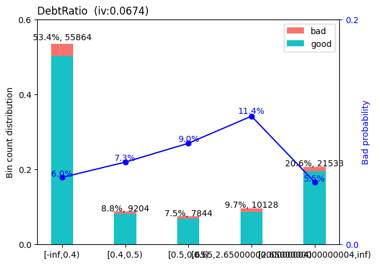

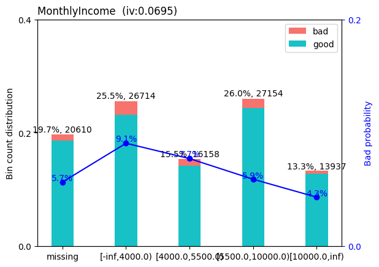

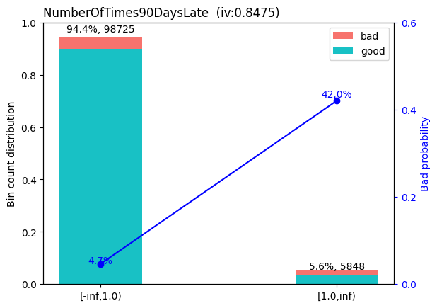

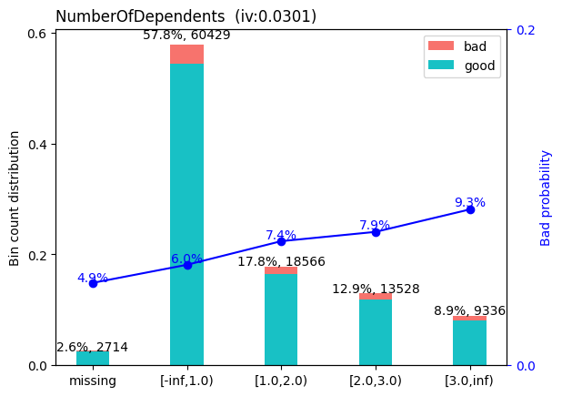

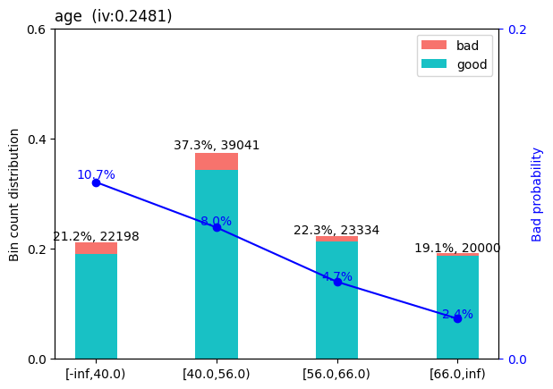

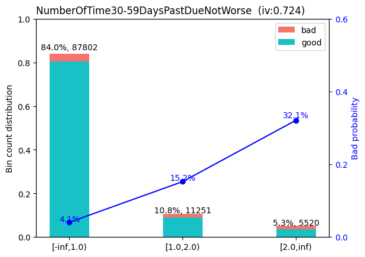

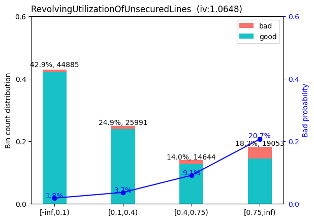

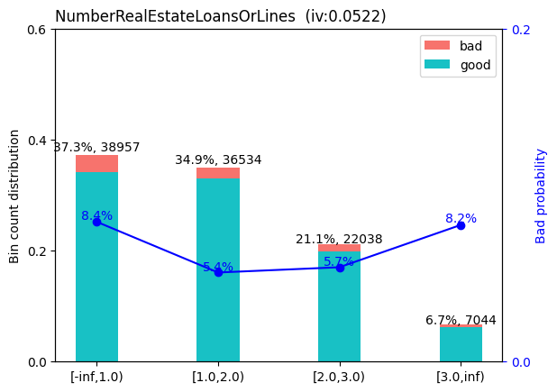

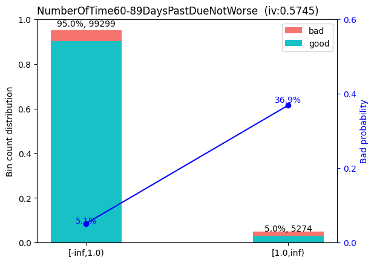

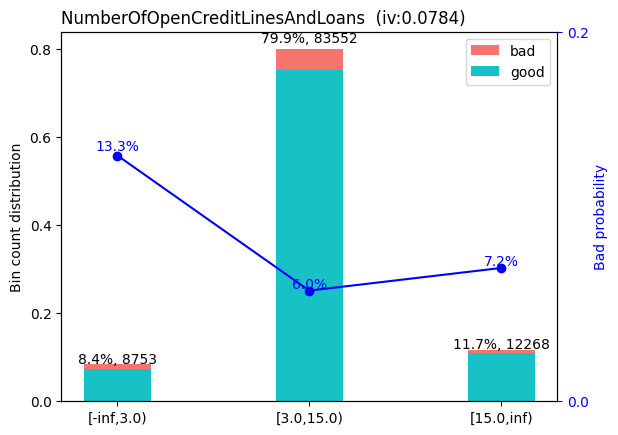

```python
sc.woebin_plot(bins)
```

Prawdopodobieństwo poważnych trudności ze spłatą kredytu jest monotoniczne w przypadku tylko 6 zmiennych - tych samych, dla których otrzymaliśmy monotoniczne wartości WoE. Jednoczęśnie, są to te same zmienne, dla których w trakcie analizy eksploracyjnej zaobserwowane zostały monotoniczne lub bliskie monotoniczności zależności pomiędzy wartościami regresorów a zmiennej objaśnianej.

W przypadku wielu zmiennych, liczności grup są bardzo nierówne. Najbardziej równoliczne przedziały obserwujemy dla zmiennych age, MonthlyIncome oraz RevolvingUtilizationOfUnsecuredLines.

## Wykluczenie zmiennych

Chcemy ocenić, które zmienne powinny być wykluczone z modelu. Pierwszą metodą której użyjemy jest krokowe porównanie pól pod wykresem krzywej ROC, dodając do modelu kolejne zmienne. Poniżej odczytać można zmienne obecne w modelu, który został wybrany za pomocą tego algorytmu.

```python
model2_1 = LogisticRegression()

selector = SequentialFeatureSelector(estimator = model2_1,
                                     direction = "forward",
                                    scoring = "roc_auc")
selector.fit(train_woe, y_train)

model2_1_feats = train_woe.columns[selector.get_support()]
model2_1_feats
```

```
Index(['NumberOfTimes90DaysLate_woe', 'age_woe',
       'NumberOfTime30-59DaysPastDueNotWorse_woe',
       'RevolvingUtilizationOfUnsecuredLines_woe',
       'NumberOfTime60-89DaysPastDueNotWorse_woe'],
      dtype='object')
```

Wybrane zostały wszystkie zmienne z monotonicznymi wartościami WoE, oprócz regresora reprezentującego liczbę osób na utrzymaniu. Zmienna NumberOfDependents nie została wybrana najprawdopodobniej przez małe zróżnicowanie rozkładu wartości zmiennej wynikowej w grupach.

Kolejną metodą wyboru zmiennych do odrzucenia jest podjęcie decyzji na podstawie mocy predykcyjnych (IV). Ustalmy następujące poziomy mocy predykcji w zależności od wartości IV:

- wysoka: IV > 0.3,
- średnia: 0.1 < IV <= 0.3,
- słaba: 0.015 < IV <= 0.1,
- brak: IV <= 0.015.

Poniższa tabela przedstawia wartości IV obliczone dla wszystkich zmiennych.

```python
sc.iv(train_woe.merge(y_train, left_index = True,
                      right_index = True, how= "left"),
      "SeriousDlqin2yrs")
```

|  | variable | info_value |
| --- | --- | --- |
| 5 | RevolvingUtilizationOfUnsecuredLines_woe | 1.064751 |
| 9 | NumberOfTimes90DaysLate_woe | 0.847455 |
| 7 | NumberOfTime30-59DaysPastDueNotWorse_woe | 0.724047 |
| 1 | NumberOfTime60-89DaysPastDueNotWorse_woe | 0.574530 |
| 6 | age_woe | 0.248132 |
| 0 | NumberOfOpenCreditLinesAndLoans_woe | 0.078420 |
| 2 | MonthlyIncome_woe | 0.069469 |
| 3 | DebtRatio_woe | 0.067394 |
| 8 | NumberRealEstateLoansOrLines_woe | 0.052185 |
| 4 | NumberOfDependents_woe | 0.030059 |

```python
final_chars = ["RevolvingUtilizationOfUnsecuredLines_woe", "NumberOfTimes90DaysLate_woe", "NumberOfTime30-59DaysPastDueNotWorse_woe", "NumberOfTime60-89DaysPastDueNotWorse_woe", "age_woe"]
final_chars_org = ["RevolvingUtilizationOfUnsecuredLines", "NumberOfTimes90DaysLate", "NumberOfTime30-59DaysPastDueNotWorse", "NumberOfTime60-89DaysPastDueNotWorse", "age"]
```

## Budowa modelu regresji logistycznej oraz ocena jego jakości

Korzystając z wybranych zmiennych, budujemy model regresji logistycznej ze zmienną zależną SeriousDlqin2yrs.

```python
model = LogisticRegression()
model.fit(train_woe[final_chars], y_train)
```

```
LogisticRegression()
```

Jakość otrzymanego modelu możemy ocenić za pomocą miary GINI dla zbioru testowego oraz treningowego. W tym celu grupujemy wartości zmiennych w zbiorze testowym, zgodnie z podziałem dokonanym na zbiorze treningowym.

```python
test_woe = sc.woebin_ply(X_test, bins)
```

```
[INFO] converting into woe values ...
```

Zanim przystąpimy do oceniania modelu, sprawdźmy stabilność grupowania. Na początku obliczamy miarę Herfindhal Index, określającą koncentrację wartości zmiennej w pewnych grupach. Im większa wartość HI, tym większa koncentracja oraz bardziej nierówny rozkład.

```python
for i in final_chars_org:
    print("HI dla zmiennej {0}".format(i))
    display(sum(bins[i].count_distr**2))
```

```
HI dla zmiennej RevolvingUtilizationOfUnsecuredLines
```

```
0.2988116836862285
```

```
HI dla zmiennej NumberOfTimes90DaysLate
```

```
0.894409373309573
```

```
HI dla zmiennej NumberOfTime30-59DaysPastDueNotWorse
```

```
0.7193304134584915
```

```
HI dla zmiennej NumberOfTime60-89DaysPastDueNotWorse
```

```
0.9042197731127444
```

```
HI dla zmiennej age
```

```
0.2708082028444668
```

```python
for i in final_chars:
    print("HI dla zmiennej {0} (zbiór testowy)".format(i))
    test_counts = test_woe[i].value_counts(normalize=True)
    display(sum(test_counts**2))
```

```
HI dla zmiennej RevolvingUtilizationOfUnsecuredLines_woe (zbiór testowy)
```

```
0.2985714956406837
```

```
HI dla zmiennej NumberOfTimes90DaysLate_woe (zbiór testowy)
```

```
0.8972398228234446
```

```
HI dla zmiennej NumberOfTime30-59DaysPastDueNotWorse_woe (zbiór testowy)
```

```
0.7199891837723235
```

```
HI dla zmiennej NumberOfTime60-89DaysPastDueNotWorse_woe (zbiór testowy)
```

```
0.9031886554420985
```

```
HI dla zmiennej age_woe (zbiór testowy)
```

```
0.27201562409760605
```

Wartości HI dla zmiennych w obu podzbiorach są bardzo podobne, co sugeruje stabilne wyznaczenie grup oraz odpowiednią jakość predykcyjną wybranych zmiennych.

Poniżej obliczone zostały wartości GINI na podstawie danych testowych oraz treningowych.

```python
def gini(true_val, predicted_val):
    return 2 * roc_auc_score(true_val, predicted_val) - 1

gini(true_val = y_train, predicted_val = model.predict_proba(train_woe[final_chars])[:, 1])
```

```
0.7020816837838841
```

```python
gini(true_val = y_test, predicted_val = model.predict_proba(test_woe[final_chars])[:, 1])
```

```
0.7012506541847385
```

Wartości GINI są bardzo podobne w obu przypadkach, co świadczy o stabilności modelu oraz braku przeuczenia.

- PSI < 10%: stabilnie,
- 10% <= PSI < 25%: średnia stabilność,
- PSI >= 25%: niska stabilność.

Poniżej przedstawione zostały informacje dotyczące nowych podziałów oraz wartości PSI.

```python
bins_test = sc.woebin(X_test.merge(y_test, left_index = True, right_index = True, how = "left"), y = "SeriousDlqin2yrs")

for i in final_chars_org:
    df_stab = bins[i][["variable", "bin", "woe", "count", "count_distr"]]
    df_stab = df_stab.merge(test_woe[i + "_woe"].value_counts(normalize = True), left_on = "woe", right_index = True, how = "left")
    df_stab = df_stab.rename(columns = {i + "_woe": "count_distr_test"})
    print("Wartość PSI dla zmiennej {0} wynosi:".format(i))
    display(100*(df_stab.count_distr - df_stab.count_distr_test)*np.log(df_stab.count_distr / df_stab.count_distr_test).sum().round(2))
    display(df_stab)
```

```
[INFO] creating woe binning ...
Wartość PSI dla zmiennej RevolvingUtilizationOfUnsecuredLines wynosi:
```

```
0   -0.0
1    0.0
2    0.0
3    0.0
dtype: float64
```

|  | variable | bin | woe | count | count_distr | count_distr_test |
| --- | --- | --- | --- | --- | --- | --- |
| 0 | RevolvingUtilizationOfUnsecuredLines | [-inf,0.1) | -1.349934 | 44885 | 0.429222 | 0.428632 |
| 1 | RevolvingUtilizationOfUnsecuredLines | [0.1,0.4) | -0.642868 | 25991 | 0.248544 | 0.248968 |
| 2 | RevolvingUtilizationOfUnsecuredLines | [0.4,0.75) | 0.327247 | 14644 | 0.140036 | 0.140103 |
| 3 | RevolvingUtilizationOfUnsecuredLines | [0.75,inf) | 1.282062 | 19053 | 0.182198 | 0.182297 |

```
Wartość PSI dla zmiennej NumberOfTimes90DaysLate wynosi:
```

```
0   -0.004772
1    0.004772
dtype: float64
```

|  | variable | bin | woe | count | count_distr | count_distr_test |
| --- | --- | --- | --- | --- | --- | --- |
| 0 | NumberOfTimes90DaysLate | [-inf,1.0) | -0.393408 | 98725 | 0.944077 | 0.945668 |
| 1 | NumberOfTimes90DaysLate | [1.0,inf) | 2.305976 | 5848 | 0.055923 | 0.054332 |

```
Wartość PSI dla zmiennej NumberOfTime30-59DaysPastDueNotWorse wynosi:
```

```
0    0.0
1   -0.0
2    0.0
dtype: float64
```

|  | variable | bin | woe | count | count_distr | count_distr_test |
| --- | --- | --- | --- | --- | --- | --- |
| 0 | NumberOfTime30-59DaysPastDueNotWorse | [-inf,1.0) | -0.535714 | 87802 | 0.839624 | 0.840105 |
| 1 | NumberOfTime30-59DaysPastDueNotWorse | [1.0,2.0) | 0.911095 | 11251 | 0.107590 | 0.106678 |
| 2 | NumberOfTime30-59DaysPastDueNotWorse | [2.0,inf) | 1.877643 | 5520 | 0.052786 | 0.053216 |

```
Wartość PSI dla zmiennej NumberOfTime60-89DaysPastDueNotWorse wynosi:
```

```
0   -0.000574
1    0.000574
dtype: float64
```

|  | variable | bin | woe | count | count_distr | count_distr_test |
| --- | --- | --- | --- | --- | --- | --- |
| 0 | NumberOfTime60-89DaysPastDueNotWorse | [-inf,1.0) | -0.287967 | 99299 | 0.949566 | 0.948993 |
| 1 | NumberOfTime60-89DaysPastDueNotWorse | [1.0,inf) | 2.089346 | 5274 | 0.050434 | 0.051007 |

```
Wartość PSI dla zmiennej age wynosi:
```

```
0   -0.000794
1   -0.003216
2    0.000341
3    0.003669
dtype: float64
```

|  | variable | bin | woe | count | count_distr | count_distr_test |
| --- | --- | --- | --- | --- | --- | --- |
| 0 | age | [-inf,40.0) | 0.503968 | 22198 | 0.212273 | 0.213066 |
| 1 | age | [40.0,56.0) | 0.177681 | 39041 | 0.373337 | 0.376554 |
| 2 | age | [56.0,66.0) | -0.391065 | 23334 | 0.223136 | 0.222795 |
| 3 | age | [66.0,inf) | -1.063816 | 20000 | 0.191254 | 0.187585 |

## Karta scoringowa

Na podstawie utworzonego modelu wyznaczamy scory dla każdej zmiennej oraz grupy, zgodnie ze wzorem

$$ SCORE_{i,j}=\frac{PEO}{k}-\frac{PDO}{\log2}\left(X^{WoE}_{i,j}\beta_i+\frac{\beta_0}{k}\right), $$

gdzie:

- $PEO = 500$,
- $PDO = 20$,
- $k$ - liczba zmiennych w modelu,
- $X^{WoE}_{i,j}$ - wartość WoE dla $i$-tej zmiennej i jej $j$-tego bucketu,
- $\beta_i$ - współczynniki modelu regresji logistycznej,
- $\beta_0$ - wyraz wolny modelu.

Poniżej obliczona została finalna karta scoringowa, zawierające zsumowane pojedyncze scory dla każdej obserwcji.

```python
PEO = 500
PDO = 20
k = 5
beta_0 = model.intercept_

df_results = pd.DataFrame({
    "score": (PEO/k - PDO/np.log(2) * (list(model.coef_[0]) * train_woe[final_chars] + model.intercept_[0]/k)).sum(axis = 1),
    "pd": model.predict_proba(train_woe[final_chars])[:, 1]
})

df_results
```

|  | score | pd |
| --- | --- | --- |
| 25777 | 597.760701 | 0.032669 |
| 45895 | 618.882485 | 0.015982 |
| 17572 | 562.084600 | 0.104174 |
| 38669 | 591.839080 | 0.039814 |
| 44619 | 615.261110 | 0.018081 |
| ... | ... | ... |
| 120294 | 615.261110 | 0.018081 |
| 104020 | 566.480465 | 0.090789 |
| 132432 | 622.923467 | 0.013923 |
| 147458 | 615.261110 | 0.018081 |
| 122387 | 580.130088 | 0.058574 |

104573 rows × 2 columns

Punkty scoringowe mieszczą się w przedziale [0,1000]. Im większa liczba punktów, tym lepszy jest klient, co zgadza się z wyznaczonymi w kolumnie pd prawdopodobieństwami wystąpienia poważnych problemów w spłacie kredytu w ciągu następnych dwóch lat.